# Export and Import Trends of Myanmar: 2019 vs 2022

Name - Thu Thu San

Student ID - 201925916

Total word counts - 995 words

# Introduction

This project conveys the comparison between Myanmar export and import values between 2019 (pre-pandemic) and 2022 (post-pandemic and regime change in 2021) in US billion dollars. Since February 1, 2021, Myanmar military seized power from the democratic civilian government, leading to a series of mass protests and instability across the country (Nayt, T., Zin, K., Naung, N., 2025). Both pandemic and political instability have pushed Myanmar economy to the blink (*BBC*, 2021) .

The trading sector has been severely impacted because of these two double crises. The aim of the project is to highlight shift in trade values between partner countries for the years, 2019 and 2022. As the trading sector is vast, only top six partner countries based on trade values are analyzed in the report.

The dataset used in this project is referenced from World Integrated Trade Solution (WITS) website.

# Data

The World Bank, in collaboration with the United Nations Conference on Trade and Development (UNCTAD), International Trade Center, United Nations Statistical Division (UNSD) and the World Trade Organization (WTO) — developed the World Integrated Trade Solution (WITS). The website allows users to access and download information on trade and tariffs for free (World Integrated Trade Solution, 1997).

The World Integrated Trade Solution (WITS) provides access to international merchandise trade, tariff and non-tariff measures data. Users can browse the country profile section to obtain countries exports, imports and tariff statistics along with relevant development data.

For this project, Myanmar's export and import data are selected to analyze the shift in trade values for 2019 and 2022. The dataset provides the complete picture of the trade sector such as number of exported/imported Harmonized System (HS) 6 digit products, export/import share in total products (%), trade balance and export/import values in US$. However, the project focuses only on the trade values of top six partner countries for the years, 2019 and 2022, with 2022 being the most recent year available on the WITS website.

```python
import pandas as pd
import numpy as np
import seaborn as sns
import matplotlib.pyplot as plt
```

```python
df=pd.read_excel("WITS-ExportImport-Partner-2019-2022.xlsx")
#Import the excel file and assign into a dataframe named df
#(World Intergrated Trade Solution, 1997)
```

```python
len(df)
#Find out number of rows in the dataframe
```

```
298
```

```python
df.count()
#Count unique value of the dataframe
```

```
No                                    298
Partner Name                          298
Year                                  298
Trade Flow                            298
No Of exported HS6 digit Products     298
No Of imported HS6 digit Products     298
Export Share in Total Products (%)    298
Import Share in Total Products (%)    298
Trade Balance (US$)                   298
Export (US$)                          298
Import (US$)                          298
dtype: int64
```

```python
#There is no null value in the dataset.
```

```python
df
#The original dataset has 298 rows and 11 columns but only 4 columns which are Partner Name, Year, Export (US$) and Import (US$) are used in the project as it focuses on the trade value of partner countries.
#The Partner Name column includes all trading partner countries of Myanmar.
#The Year column includes two years, 2019 and 2022.
#The Export and Import value unit is in US dollars.
```

|  | No | Partner Name | Year | Trade Flow | No Of exported HS6 digit Products | No Of imported HS6 digit Products | Export Share in Total Products (%) | Import Share in Total Products (%) | Trade Balance (US$) | Export (US$) | Import (US$) |
| --- | --- | --- | --- | --- | --- | --- | --- | --- | --- | --- | --- |
| 0 | 1 | Afghanistan | 2019 | Exports & Imports | 1 | 3 | 0.06 | 0.08 | -1318420.0 | 13730.0 | 1332150.0 |
| 1 | 2 | Albania | 2019 | Exports & Imports | 3 | 29 | 0.19 | 0.76 | 110200.0 | 226690.0 | 116490.0 |
| 2 | 3 | United Arab Emirates | 2019 | Exports & Imports | 209 | 263 | 12.92 | 6.89 | -97186230.0 | 99453580.0 | 196639810.0 |
| 3 | 4 | Argentina | 2019 | Exports & Imports | 42 | 36 | 2.60 | 0.94 | 211570.0 | 3092050.0 | 2880480.0 |
| 4 | 5 | Armenia | 2019 | Imports | 0 | 1 | 0.00 | 0.03 | -280.0 | 0.0 | 280.0 |
| ... | ... | ... | ... | ... | ... | ... | ... | ... | ... | ... | ... |
| 293 | 294 | Vietnam | 2022 | Exports & Imports | 223 | 941 | 16.74 | 26.27 | -153847570.0 | 240947510.0 | 394795080.0 |
| 294 | 295 | Yemen | 2022 | Exports & Imports | 4 | 2 | 0.30 | 0.06 | 117610.0 | 291640.0 | 174030.0 |
| 295 | 296 | South Africa | 2022 | Exports & Imports | 112 | 41 | 8.41 | 1.14 | 12791510.0 | 13914520.0 | 1123010.0 |
| 296 | 297 | Zambia | 2022 | Imports | 0 | 2 | 0.00 | 0.06 | -848550.0 | 0.0 | 848550.0 |
| 297 | 298 | Zimbabwe | 2022 | Imports | 0 | 1 | 0.00 | 0.03 | -20.0 | 0.0 | 20.0 |

298 rows × 11 columns

```python
#As the original dataset, df, is showing both export and import in one column as Trade Flow, the following 4 variables are developed to filter values for export and import by year.

topExport2019 = df.loc[df['Year'] == 2019].sort_values("Export (US$)", ascending=False).head(6)
#Filter only top 6 export values in descending order for 2019 from the dataset and assign in the variable, topExport2019

topExport2022 = df.loc[df['Year'] == 2022].sort_values("Export (US$)", ascending=False).head(6)
#Filter only top 6 export values in descending order for 2022 from the dataset and assign in the variable, topExport2022

topImport2019 = df.loc[df['Year'] == 2019].sort_values("Import (US$)", ascending=False).head(6)
#Filter only top 6 import values in descending order for 2019 from the dataset and assign in the variable, topImport2019

topImport2022 = df.loc[df['Year'] == 2022].sort_values("Import (US$)", ascending=False).head(6)
#Filter only top 6 import values in descending order for 2022 from the dataset and assign in the variable, topImport2019
```

```python
df_trade=pd.concat([topExport2019, topExport2022, topImport2019, topImport2022], ignore_index=True)
#Combine the 4 variables with concat function from pandas and assign in the new dataframe, df_trade
#(pandas.concat, 2025)
```

```python
df_trade
#Display the new dataframe including all top 6 import and export partner countries of Myanmar by year.
#Export and Import values are in US billion.
```

|  | No | Partner Name | Year | Trade Flow | No Of exported HS6 digit Products | No Of imported HS6 digit Products | Export Share in Total Products (%) | Import Share in Total Products (%) | Trade Balance (US$) | Export (US$) | Import (US$) |
| --- | --- | --- | --- | --- | --- | --- | --- | --- | --- | --- | --- |
| 0 | 27 | China | 2019 | Exports & Imports | 616 | 3109 | 38.07 | 81.43 | -6.934532e+08 | 5.753615e+09 | 6.447069e+09 |
| 1 | 138 | Thailand | 2019 | Exports & Imports | 470 | 2562 | 29.05 | 67.10 | 1.060919e+09 | 3.256931e+09 | 2.196013e+09 |
| 2 | 71 | Japan | 2019 | Exports & Imports | 542 | 1815 | 33.50 | 47.54 | 9.340161e+08 | 1.435526e+09 | 5.015095e+08 |
| 3 | 150 | United States | 2019 | Exports & Imports | 443 | 1351 | 27.38 | 35.38 | 4.886101e+08 | 8.351571e+08 | 3.465469e+08 |
| 4 | 37 | Germany | 2019 | Exports & Imports | 275 | 1260 | 17.00 | 33.00 | 4.316242e+08 | 6.417241e+08 | 2.100999e+08 |
| 5 | 63 | India | 2019 | Exports & Imports | 403 | 1911 | 24.91 | 50.05 | -6.681822e+07 | 6.352307e+08 | 7.020489e+08 |
| 6 | 281 | Thailand | 2022 | Exports & Imports | 519 | 2496 | 38.96 | 69.68 | 1.693698e+09 | 3.847856e+09 | 2.154159e+09 |
| 7 | 179 | China | 2022 | Exports & Imports | 451 | 3044 | 33.86 | 84.98 | -1.899383e+09 | 3.687330e+09 | 5.586713e+09 |
| 8 | 224 | Japan | 2022 | Exports & Imports | 450 | 1368 | 33.78 | 38.19 | 9.350236e+08 | 1.211865e+09 | 2.768412e+08 |
| 9 | 215 | India | 2022 | Exports & Imports | 300 | 1383 | 22.52 | 38.61 | 3.377368e+08 | 9.000702e+08 | 5.623334e+08 |
| 10 | 291 | United States | 2022 | Exports & Imports | 425 | 781 | 31.91 | 21.80 | 5.904090e+08 | 7.611631e+08 | 1.707541e+08 |
| 11 | 191 | Germany | 2022 | Exports & Imports | 234 | 791 | 17.57 | 22.08 | 5.964880e+08 | 6.798823e+08 | 8.339429e+07 |
| 12 | 27 | China | 2019 | Exports & Imports | 616 | 3109 | 38.07 | 81.43 | -6.934532e+08 | 5.753615e+09 | 6.447069e+09 |
| 13 | 122 | Singapore | 2019 | Exports & Imports | 420 | 1184 | 25.96 | 31.01 | -3.054339e+09 | 3.373566e+08 | 3.391696e+09 |
| 14 | 138 | Thailand | 2019 | Exports & Imports | 470 | 2562 | 29.05 | 67.10 | 1.060919e+09 | 3.256931e+09 | 2.196013e+09 |
| 15 | 97 | Malaysia | 2019 | Exports & Imports | 327 | 1411 | 20.21 | 36.96 | -7.464470e+08 | 1.982462e+08 | 9.446933e+08 |
| 16 | 62 | Indonesia | 2019 | Exports & Imports | 174 | 962 | 10.75 | 25.20 | -7.464156e+08 | 1.600276e+08 | 9.064432e+08 |
| 17 | 63 | India | 2019 | Exports & Imports | 403 | 1911 | 24.91 | 50.05 | -6.681822e+07 | 6.352307e+08 | 7.020489e+08 |
| 18 | 179 | China | 2022 | Exports & Imports | 451 | 3044 | 33.86 | 84.98 | -1.899383e+09 | 3.687330e+09 | 5.586713e+09 |
| 19 | 271 | Singapore | 2022 | Exports & Imports | 312 | 554 | 23.42 | 15.47 | -4.121902e+09 | 2.001792e+08 | 4.322081e+09 |
| 20 | 281 | Thailand | 2022 | Exports & Imports | 519 | 2496 | 38.96 | 69.68 | 1.693698e+09 | 3.847856e+09 | 2.154159e+09 |
| 21 | 246 | Malaysia | 2022 | Exports & Imports | 321 | 850 | 24.10 | 23.73 | -8.413613e+08 | 2.989152e+08 | 1.140276e+09 |
| 22 | 214 | Indonesia | 2022 | Exports & Imports | 193 | 610 | 14.49 | 17.03 | -9.440718e+08 | 9.367016e+07 | 1.037742e+09 |
| 23 | 215 | India | 2022 | Exports & Imports | 300 | 1383 | 22.52 | 38.61 | 3.377368e+08 | 9.000702e+08 | 5.623334e+08 |

**New data frame analysis**

China is Myanmar's main trading partner, with the highest trade values in both years. Its export values were US 5.8 billion in 2019 and US 3.7 billion in 2022. For imports, China recorded US 6.4 billion and US 5.6 billion respectively in 2019 and 2022.

It is interesting to note that top six countries of both export and import values remained the same in both 2019 and 2022. This provides a good opportunity for data visualization. Bar charts will be used to present trade values of top six countries later in the report.

```python
df_trade.describe().round(2)
#The following table shows the summary statistics of the new dataframe.
```

|  | No | Year | No Of exported HS6 digit Products | No Of imported HS6 digit Products | Export Share in Total Products (%) | Import Share in Total Products (%) | Trade Balance (US$) | Export (US$) | Import (US$) |
| --- | --- | --- | --- | --- | --- | --- | --- | --- | --- |
| count | 24.00 | 24.00 | 24.00 | 24.00 | 24.00 | 24.00 | 2.400000e+01 | 2.400000e+01 | 2.400000e+01 |
| mean | 157.58 | 2020.50 | 401.42 | 1747.79 | 27.28 | 47.13 | -2.338737e+08 | 1.792324e+09 | 2.026198e+09 |
| std | 87.00 | 1.53 | 121.33 | 854.65 | 8.00 | 23.01 | 1.429478e+09 | 1.812450e+09 | 2.109691e+09 |
| min | 27.00 | 2019.00 | 174.00 | 554.00 | 10.75 | 15.47 | -4.121902e+09 | 9.367016e+07 | 8.339429e+07 |
| 25% | 69.00 | 2019.00 | 309.00 | 1128.50 | 22.52 | 29.56 | -7.701756e+08 | 5.607622e+08 | 5.471274e+08 |
| 50% | 164.50 | 2020.50 | 422.50 | 1397.00 | 26.67 | 38.61 | 1.354593e+08 | 8.676136e+08 | 9.912176e+08 |
| 75% | 217.25 | 2022.00 | 470.00 | 2512.50 | 33.80 | 67.74 | 6.808700e+08 | 3.364531e+09 | 2.494933e+09 |
| max | 291.00 | 2022.00 | 616.00 | 3109.00 | 38.96 | 84.98 | 1.693698e+09 | 5.753615e+09 | 6.447069e+09 |

**Summary statistics of the data frame**

The first two columns, No and Year, are meaningless to describe in terms of statistics. As only the export/import values are analyzed in the report, summary statistics will focus on these two columns.

The standard deviation for exports was about US 1.81 billion, while imports showed a slightly higher value of US 2.11 billion. This means that import values varied more significantly than exports.

```python
#First, create a custom order with China and then Thailand. Without creating the custom order, the bar chart result is not showing accurately for China and Thailand.
custom_order = ['China', 'Thailand', 'Japan', 'United States', 'Germany', 'India']

#Sort the dataframes according to the custom order
topExport2019 = topExport2019.set_index('Partner Name').loc[custom_order].reset_index()
topExport2022 = topExport2022.set_index('Partner Name').loc[custom_order].reset_index()
```

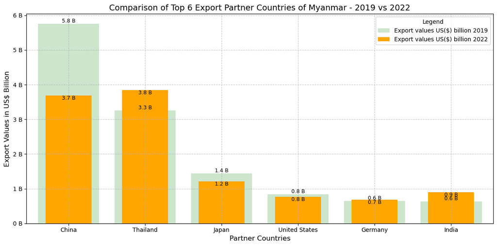

```python
#Create figure and axes with the dimensions of the figure in inches.
fig, ax = plt.subplots(figsize=(12, 6))

#Create a bar chart for both 2019 and 2029 on the same axes for the comparison.
topExport2019.plot(kind='bar', x = 'Partner Name' , y = 'Export (US$)',ax=ax, linewidth=1, color='green', alpha=0.2, width=0.8, label='Export values US($) billion 2019')
topExport2022.plot(kind='bar', x = 'Partner Name' , y = 'Export (US$)',ax=ax, linewidth=1, color='orange', width=0.6, label='Export values US($) billion 2022')

plt.title('Comparison of Top 6 Export Partner Countries of Myanmar - 2019 vs 2022', fontsize=14)
plt.xlabel('Partner Countries', fontsize=12)
plt.ylabel('Export Values in US$ Billion', fontsize=12)
plt.xticks(rotation=360)
plt.grid(True, linestyle='--', alpha=0.7)
plt.legend(title='Legend',fontsize=10)

#Format y-axis to show values in billion for better understanding
ax.get_yaxis().set_major_formatter(plt.FuncFormatter(lambda x, loc: "{:,}".format(int(x/1000000000)) + ' B'))
#(GeeksforGeeks, 2025)

#Add value labels in the chart for better visualisation
#(stack overflow, 2020)
for i, (country, value) in enumerate(zip(topExport2019['Partner Name'], topExport2019['Export (US$)'])):
    if value > 0:  # Only add labels for non-zero values
        plt.text(i, value + 200000, f'{value/1000000000:.1f} B',
                ha='center', va='bottom', fontsize=9, color='black')

for i, (country, value) in enumerate(zip(topExport2022['Partner Name'], topExport2022['Export (US$)'])):
    if value > 0:  # Only add labels for non-zero values
        plt.text(i, value + 200000, f'{value/1000000000:.1f} B',
                ha='center', va='top', fontsize=9, color='black')

plt.tight_layout()
plt.show()
```

**Comparison of Top Six Export Partner Countries of Myanmar - 2019 vs 2022**

The above bar chart analyzes Myanmar's top six export partners, comparing trade values between 2019 (pre-pandemic) and 2022 (post-pandemic and regime change) in billion US dollars. The data shows a significant overall downward trend.

The most critical finding is the collapse of trade with China, Myanmar's largest partner, which saw exports fall significantly from US 5.8 billion in 2019 to US 3.7 billion in 2022, a loss of US 2.1 billion.

A smaller decline of US 0.2 billion was also recorded with Japan. To counter this, trade with regional neighbors, Thailand and India, showed resilience and growth, increasing by US 0.5 billion and US 0.3 billion, respectively.

In conclusion, while Myanmar's exports were growing before 2020, the combined effects of the pandemic and the regime change have led to an overall contraction of trade, as regional gains were insufficient to offset the massive decline with its primary export destination, China.

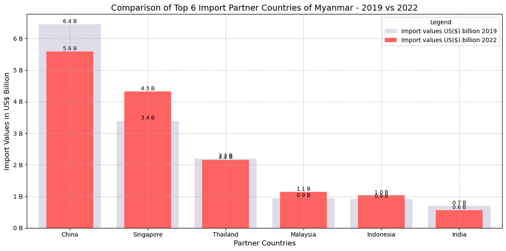

```python
#Create figure and axes with the dimensions of the figure in inches.
fig, ax = plt.subplots(figsize=(12, 6))

#Create a bar chart  for both 2019 and 2029 on the same axes for the comparison.
topImport2019.plot(kind='bar', x = 'Partner Name' , y = 'Import (US$)',ax=ax, linewidth=1.2, color='#58508d', alpha=0.2, width=0.8, label='Import values US($) billion 2019',fontsize=10)
topImport2022.plot(kind='bar', x = 'Partner Name' , y = 'Import (US$)',ax=ax, linewidth=1.2, color='#ff6361', width=0.6, label='Import values US($) billion 2022',fontsize=10)

plt.title('Comparison of Top 6 Import Partner Countries of Myanmar - 2019 vs 2022', fontsize=14)
plt.xlabel('Partner Countries', fontsize=12)
plt.ylabel('Import Values in US$ Billion', fontsize=12)
plt.xticks(rotation=360)
plt.grid(True, linestyle='--', alpha=0.7)
plt.legend(title='Legend',fontsize=10)

#Format y-axis to show values in billion for better understanding
ax.get_yaxis().set_major_formatter(plt.FuncFormatter(lambda x, loc: "{:,}".format(int(x/1000000000)) + ' B'))
#(GeeksforGeeks, 2025)

#Add value labels to the chart for better visualisation
#(stack overflow, 2020)
for i, (country, value) in enumerate(zip(topImport2019['Partner Name'], topImport2019['Import (US$)'])):
    if value > 0:  # Only add labels for non-zero values
        plt.text(i, value + 200000, f'{value/1000000000:.1f} B',
                ha='center', va='bottom', fontsize=9, color='black')

for i, (country, value) in enumerate(zip(topImport2022['Partner Name'], topImport2022['Import (US$)'])):
    if value > 0:  # Only add labels for non-zero values
        plt.text(i, value + 200000, f'{value/1000000000:.1f} B',
                ha='center', va='bottom', fontsize=9, color='black')

plt.tight_layout()
plt.show()
```

**Comparison of Top Six Import Partner Countries of Myanmar - 2019 vs 2022**

The largest import partner, China, experienced a significant reduction, falling from US 6.4 billion to US 5.6 billion. However, the second-largest import partner, Singapore, showed strong growth, moving from US 3.4 billion up to US 4.3 billion.

Meanwhile, Malaysia's imports increased by US 0.2 billion, and Indonesia's imports were up by US 0.1 billion.

# Conclusion

While the larger markets fluctuated, Myanmar's trade structure shifted towards regional resilience. Trade with ASEAN neighbors, especially Singapore, Thailand, and India, showed necessary increases in certain categories such as imports from Singapore, exports to Thailand and India.

In summary, while regional relationships helped stabilize essential supply chains, these limited gains were insufficient to cover the massive loss of volume from the largest, most significant trade partner, which results in a negative overall economic impact.

Due to limitation in time and resources, only top six trading partners are analyzed in the project for 2019 and 2022, with 2022 being the most recent year available on the WITS website.

There are still scopes for future research, particularly in analyzing the effects of foreign policies, regional power conflicts, forthcoming national election and the possible regime change after January 2026 on Myanmar’s economy and trade.

# References

- World Intergrated Trade Solution (1997) *Myanmar trade balance, exports and imports by country and region 2019.* Available at:https:*//wits.worldbank.org/CountryProfile/en/Country/MMR/Year/2019/TradeFlow/EXPIMP* (Accessed: 14 October 2025).
- World Intergrated Trade Solution (1997) *Myanmar trade balance, exports and imports by country and region 2022.* Available at:https:*//wits.worldbank.org/CountryProfile/en/Country/MMR/Year/2022/TradeFlow/EXPIMP* (Accessed: 14 October 2025).
- World Intergrated Trade Solution (1997) *About WITS* Available at: https://*wits.worldbank.org/about_wits.html* (Accessed: 14 October 2025).
- *Cite Them Right* (2025) Available at: https://www-citethemrightonline-com.liverpool.idm.oclc.org/sourcetype?docid=b-9781350927964&tocid=b-9781350927964-159 (Accessed: 25 October 2025).
- *pandas.concat* (2025) Available at: https://www-citethemrightonline-com.liverpool.idm.oclc.org/sourcetype?docid=b-9781350927964&tocid=b-9781350927964-159 (Accessed: 22 October 2025).
- stack overflow (2020) *How to add value labels on a bar chart* Available at: https://stackoverflow.com/questions/28931224/how-to-add-value-labels-on-a-bar-chart (Accessed: 17 October 2025)
- GeeksforGeeks (2025) *Matplotlib.axis.Axis.set_major_formatter() function in Python.* Available at: https://www.geeksforgeeks.org/python/matplotlib-axis-axis-set_major_formatter-function-in-python/ (Accessed: 22 October 2025).
- *BBC* (2021) 'Covid and a coup: The double crisis pushing Myanmar to the brink', 30 July, Available at: https://www.bbc.co.uk/news/world-asia-57993930
- Nayt, T., Zin, K., Naung, N.(2025) 'Myanmar Before and After the 2021 Military Coup', *The Irrawaddy*, 1 February, Available at: https://www.irrawaddy.com/news/burma/myanmar-before-and-after-the-2021-military-coup.html